# Statistical Inference

Chelsea Parlett-Pelleriti

# The Problem Of Inference

## Review

- **Description**: What is in this data?
- **Prediction**: What will future values of similar data be?
- **Inference**: What can we learn about the population?

## Why Do We Need Inference?

**In your groups:** You want to know whether a new anti-acid reduces people’s heartburn.

Think about how you might go about using data to answer this question.

## Definition

Statistical Inference is using information/data from a **sample** to draw conclusions about a **population**

$\mathbf{X} = \left(X_1, X_2, ... X_n \right)$ is a sample of data from a distribution $P_{\theta}$. We want to use $\mathbf{X}$ to learn about $P_{\theta}$ since we can’t directly observe $P_{\theta}$.

## Definition

Statistical Inference is using information/data from a **sample** to draw conclusions about a **population**

$\mathbf{X} = \left(X_1, X_2, ... X_n \right)$ is a sample of data from a distribution $P_{\theta}$. We want to use $\mathbf{X}$ to learn about $P_{\theta}$ since we can’t directly observe $P_{\theta}$.

For example:

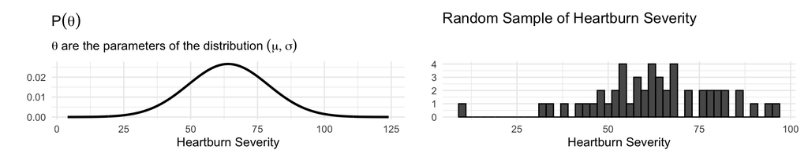

## Definition

Statistical Inference is using information/data from a **sample** to draw conclusions about a **population**

$\mathbf{X} = \left(X_1, X_2, ... X_n \right)$ is a sample of data from a distribution $P_{\theta}$. We want to use $\mathbf{X}$ to learn about $P_{\theta}$ since we can’t directly observe $P_{\theta}$.

Populations can be thought of as:

- groups of existing “experimental units”
- A Data Generating Process (DGP)

## Populations

Think about the *heights* of all people in the USA named Michael.

- Group of Existing People: All 3.28M Michaels
- DGP for Michaels: the theoretical process that creates Michaels

[figure not shown]

## Populations

Think about the *average revenue* for all of my customers.

- Group of Existing People: All 500M current customers.
- DGP for Customers: the theoretical process of all potential customers.

## Intuition

I claim that I’m faster at crosswords than you. We both do one crossword:

- my time: 25m 05s
- your time: 25m 23s

Am I right? What would it take to convince you I’m right?

## Intuition

I had a good day.

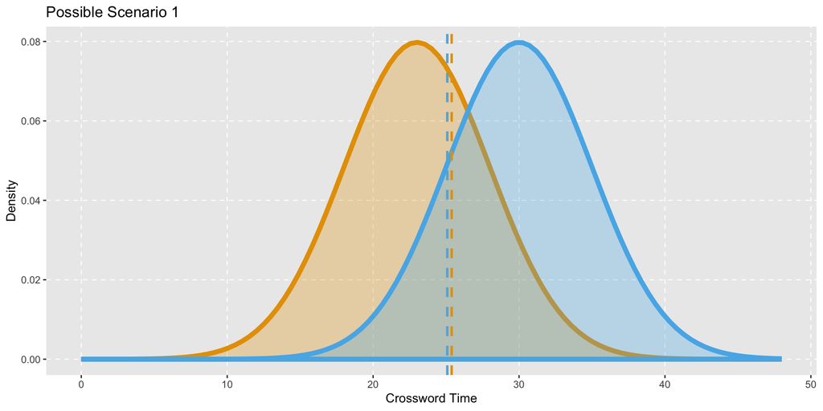

## Intuition

I’m a little better.

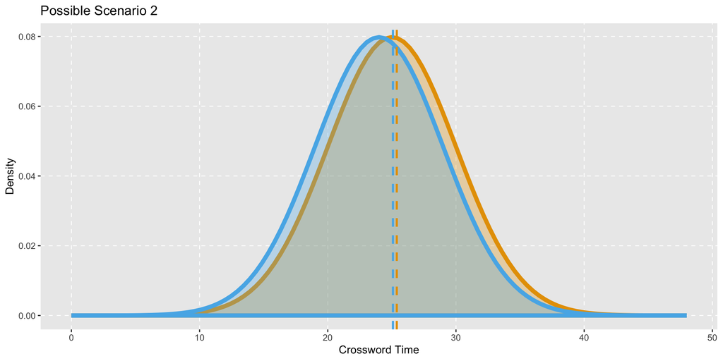

## Intuition

I’m chaotic.

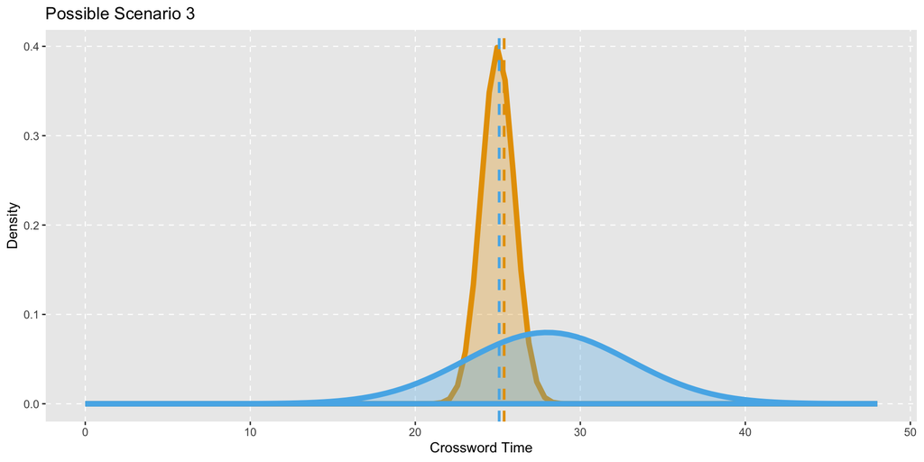

## Inference: First Problem

What do I *really* mean when I say that I’m faster at crosswords that you?

Let’s “operationalize” my statement.

## Inference: First Problem

Statistics: are functions of data that **summarize** the data, $T(\mathbf{X})$.

- **Population Statistic**: $T(\mathbf{X})$; where $\mathbf{X}$ is the random variable (e.g. mean height of people named Michael)
- **Sample Statistic**: $T(\mathbf{x})$; where $\mathbf{x}$ is a realized *sample* of $\mathbf{X}$ (e.g. mean of 100 randomly sampled heights of people named Michael)

## Inference: First Problem

Example, **Sample Mean**: $\frac{1}{N} \sum_{i=1}^N x_i$  
(or: 67th percentile, min, max, variance, z-statistic…)

- **Pros**: statistics summarize information about the data in an easily digestible way
- **Cons**: they often throw out information

## Inference: First Problem

When choosing a statistic, you’re implicitly agreeing that two samples are the same if $T(\mathbf{x}) = T(\mathbf{y})$

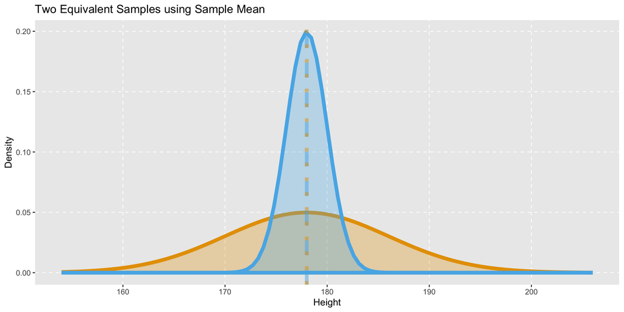

## Statistics

Simplify so we can do something useful.

[figure not shown]

New York Subway System

## Back to Crosswords

I claim that my *mean* crossword time is faster than yours:

**Note**: here, let’s think of our mean times as the DGP that generates our observed times:

$$\text{Chelsea}_i \sim N \left (\mu_{me}, \sigma_{me} \right) \\
\text{You}_i \sim N \left (\mu_{you}, \sigma_{you} \right)$$

## Back to Crosswords

But I can’t possibly observe $\mu_{me}$ and $\mu_{you}$…

## Sample $\to$ Population

If we were doing **description**, the sample mean alone would accomplish our goal.

- what is the mean crossword time?
  - my time: 25m 05s
  - your time: 25m 23s

But if doing inference, we want to *generalize*. We don’t want to know about $\bar{x}$, we want to know about $\mu$.

Note: we often use *Greek* letters to denote population statistics and *Roman* letters for sample statistics.

## Sample $\to$ Population

**New Goal**: Formalize a process to get from Sample statistics to Population statistics  
e.g. what can I learn about the mean height of college students, $\mu$ from random sample mean $\bar{x}$

## Estimands, Estimator, Estimates

[figure not shown]

via Peter Tennant at https://x.com/PWGTennant/status/1164084443742691328

## Estimands, Estimator, Estimates

- **Estimand**: a target quantity to be estimated
  - $\mu$ mean height of all people named Michael in the US
- **Estimator**: a function, $W(\mathbf{x})$ that is a *recipe* about how to get an estimate from a sample
  - $\bar{x} = W(\mathbf{heights}) = \frac{1}{N} \sum_{i=1}^N height_i$
- **Estimate**: a realized value of $W(\mathbf{x})$ applied to an actual sample, $\mathbf{x}$
  - $\bar{x} = W(176,177,175,179,173) = 176$

# Choosing an Estimator

## Finding an Estimator

Sometimes, finding an estimator for your desired estimand *feels* intuitive (e.g. using sample mean to estimate population mean) but remember, someone at some point had to figure out that the sample mean was a good estimator.

1. Method of Moments
2. Maximum Likelihood Estimators
   - Expectation Maximization (EM)

## Finding an Estimator: MOM

### Method of Moments

Set the first $k$ sample moments equal to the first $k$ population moments, and solving.

$$\underbrace{m_1}_\text{1st samp moment} = \overbrace{\mu'_1}^\text{1st population moment} \\
m_2 = \mu'_2 \\
... \\
m_n = \mu'_n \\$$

## Review: Moments

**Moments** of a distribution are expectations.

$$\mu'_n = \mathbb{E}X^n$$

**Central Moments** replace $X$ with the mean centered value $X-\mu$.

$$\mu_n = \mathbb{E}(X-\mu)^n$$

## Finding an Estimator: MOM

### Method of Moments

Remember:

- $p^{th}$ sample moment: $\frac{1}{n} \sum_{i=1}^n X_i^p$
- $p^{th}$ population moment: $\mathbb{E}(X^p)$

## Finding an Estimator: MOM

### [Method of Moments](https://online.stat.psu.edu/stat415/lesson/1/1.4)

Let’s say $x \sim \mathcal{N}(\theta, \sigma^2)$, $k = 2$

- **first moment**: $\frac{1}{n} \sum_{i=1}^n x_i= \mathbb{E}(X) = \mu$
  - $\hat{\mu} = \bar{x}$
- **second moment**: $\frac{1}{n} \sum_{i=1}^n x_i^2 = \mathbb{E}(X^2) = Var(X) + \mathbb{E}(X)^2 = \sigma^2 + \mu^2$
  - $\frac{1}{n} \sum_{i=1}^n x_i^2 = \bar{x}^2 + \sigma^2$
  - $\hat{\sigma}^2 = \left [\frac{1}{n} \sum_{i=1}^n x_i^2 \right] - \bar{x}^2 = \frac{1}{n} \sum_{i=1}^n (x_i - \bar{x})^2$

## Finding an Estimator: MOM

okay but that felt too easy…

## Finding an Estimator: MOM

A gamma distribution has two parameters, $\alpha$ and $\theta$. Let’s use MoM to find estimators for them.

$$f(x; \alpha, \theta) = \frac{1}{\Gamma(\alpha)\theta^\alpha} x^{\alpha-1} e^{-x/\theta}$$

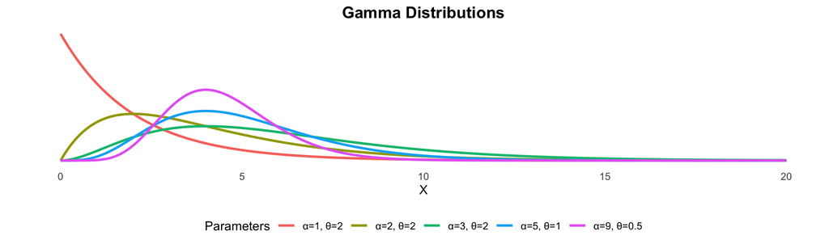

## Finding an Estimator: MOM

First moment:
$$\mathbb{E}(X_i) = \mu = \alpha\theta$$
Second central moment:
$$Var(X_i) = \mathbb{E}\left[ (X_i - \mu)^2\right ] = \alpha\theta^2$$

## Finding an Estimator: MOM

Next, we set these equal to the sample moments:
$$\mathbb{E}(X_i) = \mu = \alpha\theta = \underbrace{\frac{1}{n}\sum x_i}_\text{sample mean} = \bar{x}$$

$$Var(X_i) = \mathbb{E}\left[ (X_i - \mu)^2\right ] = \alpha\theta^2 = \underbrace{\frac{1}{n}\sum (x_i-\bar{x})^2}_\text{sample var}$$

## Finding an Estimator: MOM

Now solve for each parameter!

Try it yourself!

## Finding an Estimator: MOM

Now solve for each parameter!

$\alpha$:

$$\alpha\theta = \underbrace{\frac{1}{n}\sum x_i}_\text{sample mean} \\
\alpha = \frac{1}{n\theta}\sum x_i = \frac{\bar{x}}{\theta}$$

## Finding an Estimator: MOM

Now solve for each parameter!

using $\alpha = \frac{\bar{x}}{\theta}$ to sub into the variance equation…

$$\alpha\theta^2 = \frac{\bar{x}}{\theta}\theta^2 = \bar{x}\theta = \underbrace{\frac{1}{n}\sum (x_i-\bar{x})^2}_\text{sample var} \rightarrow \\
\hat{\theta} = \underbrace{\frac{1}{n\bar{x}}\sum (x_i-\bar{x})^2}_\text{MoM estimator}$$

## Finding an Estimator: MOM

Now plug this back into our original equation to get $\alpha$:

$$\hat{\alpha} = \frac{\bar{x}}{\hat{\theta}} = \frac{\bar{x}}{\frac{1}{n\bar{x}}\sum (x_i-\bar{x})^2}$$

## Finding an Estimator: MOM

We’ve found the estimators!!!!

$$\hat{\alpha} = \frac{\bar{x}}{\frac{1}{n\bar{x}}\sum (x_i-\bar{x})^2} \\
\hat{\theta} = \frac{1}{n\bar{x}}\sum (x_i-\bar{x})^2$$

hoorah.

## Finding an Estimator: MLE

### Maximum Likelihood Estimation

$$\text{arg}\,\max\limits_{\theta} \mathcal{L}(\theta|x)$$

The estimate of $\theta$ is the one that maximize the likelihood of the data, $x$.

## Maximum Likelihood Estimation

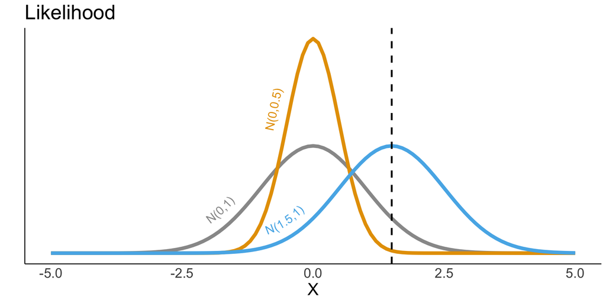

## Maximum Likelihood Estimation

$$p(x | \theta) = \frac{1}{\sqrt{2\pi\sigma^2}}e^{-\frac{x- \mu}{2\sigma^2}}$$
Where $\theta = (\mu, \sigma)$. We want to choose values of $\theta$ maximize the likelihood of the data, $x$

## Maximum Likelihood Estimation

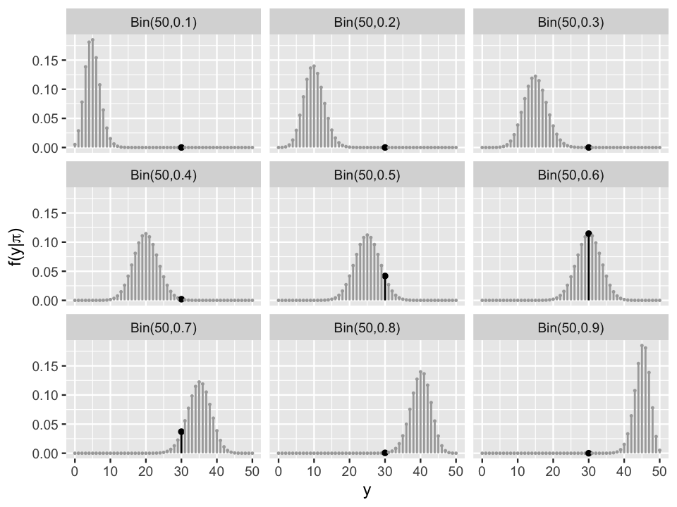

from Bayes Rules!

## Maximum Likelihood Estimation

For a single data point the value of the likelihood function, $L\left( \theta | x \right)$ is:

$$\mathcal{L} \left( \theta | x\right) = p(x| \theta) = \frac{1}{\sqrt{2\pi\sigma^2}}e^{-\frac{x- \mu}{2\sigma^2}}$$

If data points in a sample are independent, the likelihood value for *all* data points is simply the product of their individual likelihood values, since $p(A,B) = p(A)*p(B) \text{ iff } A \mathrel{\unicode{x2AEB}} B$.
$$\mathcal{L}\left(\theta | \mathbf{x} \right) = p(\mathbf{x} |\theta) = \prod_{i=1}^n p(x_i | \theta) = \prod_{i=1}^n\frac{1}{\sqrt{2\pi\sigma^2}}e^{-\frac{x_i- \mu}{2\sigma^2}}$$

## Maximum Likelihood Estimation

The higher the *likelihood* of our data, the more *evidence* that a particular $\theta$ is a good fit for the data.

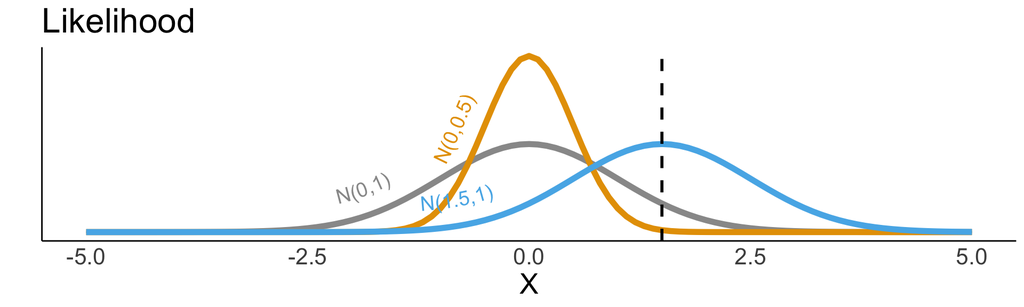

## Maximum Likelihood Estimation

$$\text{arg max}_{\theta} \left[ \prod_{i=1}^n\frac{1}{\sqrt{2\pi\sigma^2}}e^{-\frac{y_i- \mu_i}{2\sigma^2}} \right]$$

to maximize, we:

1. take the partial derivatives of $\prod_{i=1}^n\frac{1}{\sqrt{2\pi\sigma^2}}e^{-\frac{y_i- \mu_i}{2\sigma^2}}$ w.r.t. each element of $\theta$
2. set each $\frac{\partial}{\partial \theta_i} = 0$
3. solve (analytically, Expectation Maximization, Gradient Descent…) for $\theta$

But…

## Maximum Likelihood Estimation

…taking the derivative of a function of products is hard, so we use **log likelihood**.

$$\ell\left(\theta | \mathbf{x} \right) = \log\left(\mathcal{L}\left(\theta | \mathbf{x} \right)\right) = \\ -\frac{n}{2} \log(2\pi) - \frac{n}{2} \log (\sigma^2) -\frac{1}{2 \sigma^2} \sum_{i=1}^n (x_i - \mu_i)^2$$

Note: $\log()$ is a *monotonically increasing* function, so choosing $\theta$ that maximizes $\mathcal{l}\left(\theta | \mathbf{y} \right)$ will also maximize $\mathcal{L}\left(\theta | \mathbf{y} \right)$

## Maximum Likelihood Estimation

$$\ell\left(\theta | \mathbf{x} \right) = -\frac{n}{2} \log(2\pi) - \frac{n}{2} \log (\sigma^2) -\frac{1}{2 \sigma^2} \sum_{i=1}^n (x_i - \mu_i)^2$$

Example with normal distribution:

- $\hat{\mu} : \frac{\partial}{\partial \mu} \ell(\theta | x) = 0$
- $\hat{\sigma} : \frac{\partial}{\partial \sigma} \ell(\theta | x) = 0$

## Maximum Likelihood Estimation

[Solution for Normal Distribution](https://www.statlect.com/fundamentals-of-statistics/normal-distribution-maximum-likelihood):

- $\hat{\mu} = \frac{1}{n} \sum_{i=1}^nx_i$
- $\hat{\sigma} = \frac{1}{n} \sum_{i=1}^n(x_i - \hat{\mu})^2$